# Time Series Regression and Smoothing

Michael Winton

6/30/2018

## Linear Trend Time Regression

A classical linear regression would take the following form for the conditional mean:

$$y_t = \beta_0 + \beta_1 x_{t1} + \beta_2 x_{t2} + ... + \beta_k x_{tk} + \epsilon_t$$
The $\beta$ terms are the unknown regression parameters, and the $\epsilon_t$ term represents a stochastic process with random variables with $mean=0$ and $variance=\sigma_{\epsilon}^2$. If we assume the random variables follow a normal distribution, then this is the Classical Normal Linear Regression Model.

Use global temperature dataset as an example:

```r
# load dataset
url <- 'https://raw.githubusercontent.com/mwinton/Introductory_Time_Series_with_R_datasets/master/global.dat'
gtemp_df <- scan(url)
gtemp_ts <- ts(gtemp_df, start=c(1856, 1), end=c(2005, 12), freq=12)
str(gtemp_ts)
```

```
##  Time-Series [1:1800] from 1856 to 2006: -0.384 -0.457 -0.673 -0.344 -0.311 -0.071 -0.246 -0.235 -0.38 -0.418 ...
```

```r
gtemp_annual <- aggregate(gtemp_ts, FUN=mean)
str(gtemp_annual)
```

```
##  Time-Series [1:150] from 1856 to 2005: -0.381 -0.461 -0.415 -0.225 -0.37 ...
```

```r
gtemp_annual <- window(gtemp_annual, c(1880))  # to more closely match async
str(gtemp_annual)
```

```
##  Time-Series [1:126] from 1880 to 2005: -0.295 -0.245 -0.262 -0.317 -0.348 ...
```

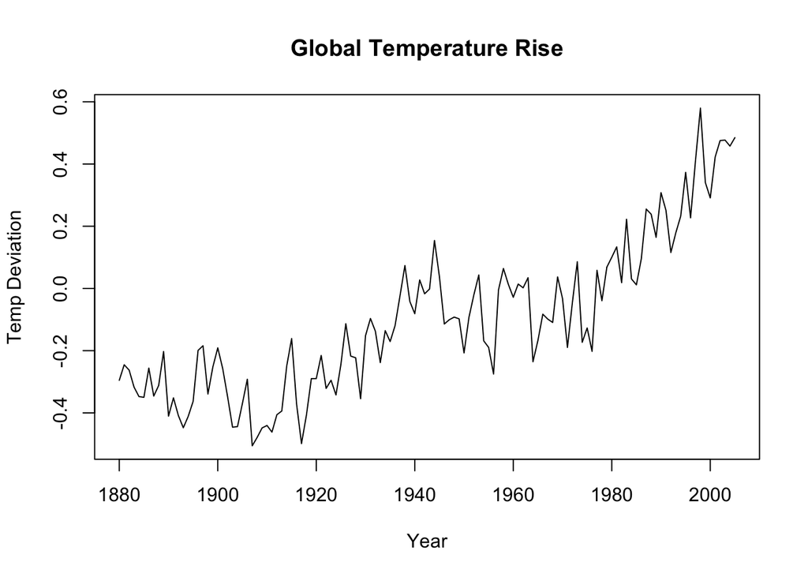

```r
# plot time series
plot(gtemp_annual, xlab="Year", ylab="Temp Deviation", main="Global Temperature Rise")
```

Observe that the temperature started to trend upwards around 1920. We can consider the following linear time trend regression model:
$$y_t = \beta_0 + \beta_1 x_{t1} +\epsilon_t$$

We can replace $t=1856, 1857, ...$ with $t=1, 2, ...$ without changing $\beta_1$; only the intercept changes. This model assumes that $\epsilon_t$ is an iid normal sequence, but we will *need to verify this later*. To estimate this regression:

```r
gtemp_lt <- lm(gtemp_annual ~ time(gtemp_annual))
summary(gtemp_lt)
```

```
##
## Call:
## lm(formula = gtemp_annual ~ time(gtemp_annual))
##
## Residuals:
##     Min      1Q  Median      3Q     Max
## -0.2937 -0.1054  0.0036  0.0871  0.3610
##
## Coefficients:
##                     Estimate Std. Error t value Pr(>|t|)
## (Intercept)        -1.13e+01   6.19e-01   -18.3   <2e-16 ***
## time(gtemp_annual)  5.78e-03   3.19e-04    18.1   <2e-16 ***
## ---
## Signif. codes:  0 '***' 0.001 '**' 0.01 '*' 0.05 '.' 0.1 ' ' 1
##
## Residual standard error: 0.13 on 124 degrees of freedom
## Multiple R-squared:  0.726,  Adjusted R-squared:  0.724
## F-statistic:  329 on 1 and 124 DF,  p-value: <2e-16
```

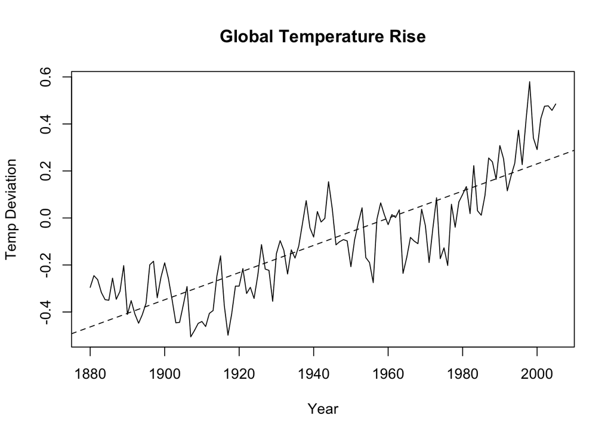

```r
plot(gtemp_annual, xlab="Year", ylab="Temp Deviation", main="Global Temperature Rise")
abline(gtemp_lt, lty=2)
```

Visually, we see that this model doesn’t do a very good job of capturing the pattern in our data, despite the relatively high Adjusted $R^2$. Performing regression diagnostics:

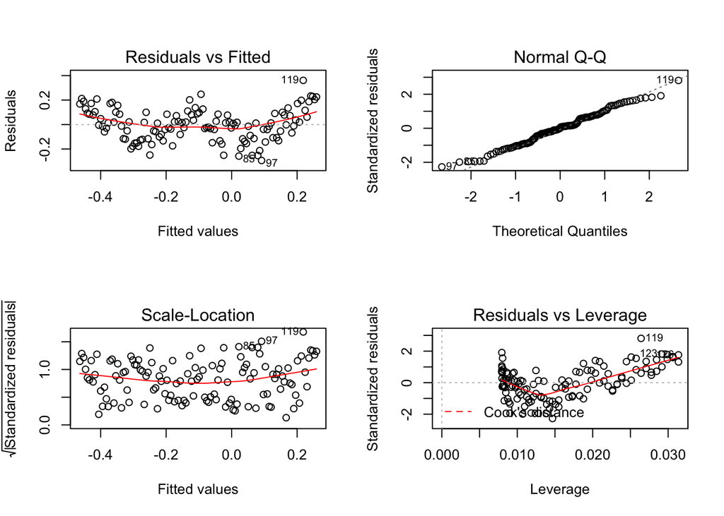

```r
par(mfrow=c(2,2))
plot(gtemp_lt)
```

```r
par(mfrow=c(1,1))

# test for heteroskedasticity (H_0: homoskedasticity)
library(lmtest)
bptest(gtemp_lt)
```

```
##
##  studentized Breusch-Pagan test
##
## data:  gtemp_lt
## BP = 3.1, df = 1, p-value = 0.08
```

We see in particular from the Residuals vs Fitted plot that we very clearly violate the zero conditional mean assumption. The plots show that may be some minor violation of the homoskedasticity assumption, but the Breusch Pagan test fails to reject the null hypothesis of homoskedasticity. Also, residuals are normally distributed.

### Goodness of Fit (AIC, AICc, BIC)

These are commonly used *in-sample* measures of goodness of fit. (We desire lower values of the IC.) These criteria all penalize the use of extra parameters in the model. BIC is the most stringent of these.

Akaike’s Information Criterion:
$$AIC = log (\hat{\sigma}_k^2) + \frac{n+2k}{n}$$

where $\hat{\sigma}_k^2 = SSE_k/n$ and $SSE_k/n = \sum_{t=1}^n(x_t - \hat{\beta}' z_t)^2$. $k$ is the number of parameters in the model, and $n$ is the sample size.

Bias-Corrected AIC:
$$AIC_c = log (\hat{\sigma}_k^2) + \frac{n+k}{n-k-2}$$

Bayesian’s Information Criterion:
$$BIC = log (\hat{\sigma}_k^2) + \frac{k \cdot log(n)}{n}$$
### Regressing one time series on another

Sometimes we want to use one time series to forecast the value of another. However, we can’t use future to forecast future, so we need to use a lag in our model.

When you are working with two time series, you need to do EDA on both, and also plot correlation between them.

The (ASTSA) textbook tells us that lag values of Southern Oscillation Index are correlated with the current value of Recruitment. We could entertain a simple model based on a 6 month lag. This would allow us to use today’s SOI value to forecast the value of Recruitment 6 months in the future.

$$R_t = \beta_1 + \beta_2 S_{t-6} + w_t$$

The `ts.intesect(...)` helps us do time series alignment.

```r
# SOI and Recruitment data is in astsa library
library(astsa)
soi_ts <- soi
str(soi_ts)
```

```
##  Time-Series [1:453] from 1950 to 1988: 0.377 0.246 0.311 0.104 -0.016 0.235 0.137 0.191 -0.016 0.29 ...
```

```r
rec_ts <- rec
str(rec_ts)
```

```
##  Time-Series [1:453] from 1950 to 1988: 68.6 68.6 68.6 68.6 68.6 ...
```

```r
# make sure to do time index alignment; new ts object includes both ts's
fish <- ts.intersect(rec_ts, soi_l6=stats::lag(soi_ts, -6))
str(fish)
```

```
##  Time-Series [1:447, 1:2] from 1950 to 1988: 59.2 48.7 47.5 50.9 44.7 ...
##  - attr(*, "dimnames")=List of 2
##   ..$ : NULL
##   ..$ : chr [1:2] "rec_ts" "soi_l6"
```

```r
# build regression model
fit2 <- lm(rec_ts ~ soi_l6, data=fish, na.action=NULL)
summary(fit2)
```

```
##
## Call:
## lm(formula = rec_ts ~ soi_l6, data = fish, na.action = NULL)
##
## Residuals:
##    Min     1Q Median     3Q    Max
## -65.19 -18.23   0.35  16.58  55.79
##
## Coefficients:
##             Estimate Std. Error t value Pr(>|t|)
## (Intercept)    65.79       1.09    60.5   <2e-16 ***
## soi_l6        -44.28       2.78   -15.9   <2e-16 ***
## ---
## Signif. codes:  0 '***' 0.001 '**' 0.01 '*' 0.05 '.' 0.1 ' ' 1
##
## Residual standard error: 22.5 on 445 degrees of freedom
## Multiple R-squared:  0.363,  Adjusted R-squared:  0.362
## F-statistic:  254 on 1 and 445 DF,  p-value: <2e-16
```

## Smoothing Techniques

Smoothing techniques are often used to under trend and cyclical components of a time series. THe general concept is to take a weighted average of values in a moving window.

### Moving (Rolling) Averages

A *symmetric* moving average smoother takes the form:

$$m_t = \sum_{j=-k}^k a_j x_{t-j}$$

where $a_j \ge 0$ and sum of the weights $\sum_{j=-k}^k a_j =1$.

For example, setting $k=2$ with weekly data essentially results in a monthly series, and can help bring out a seasonality pattern:

$$m_t = \frac{1}{5} \sum_{j=-2}^2 x_{t-j} = \frac{1}{5}[x_{t-2} + x_{t-1} + x_{t} + x_{t+1} + x_{t+2}]$$
Similarly, setting $k=26$ would essentially give a yearly series (with $a=\frac{1}{53}$). Note that some people only use backward smoothing techniques so we don’t have to rely on “future” data for each point.

### Polynomial and Periodic Regression Smoothers

This class of smoothing technique requires that we define a smoothing function $f_t$ and a $z_t$ stationary process.

$$x_t = f_t + z_t$$
We can use a polynomial function for $f_t$ (where we specify the degree of polynomial $p$):
$$f_t = \sum_{i=0}^p \beta_i t^i$$
For periodic data, we use a periodic function such as:

$$f_t = \sum_{i=0}^p \alpha_i cos(2\pi w_i t) \beta_i sin(2\pi w_i t)$$
where $cos(2\pi w_0 t) = sin(2\pi w_0 t) = 1$ and $w_1, w_2, ...w_p$ are distinct, specified frequencies.

The polynomial and periodic polynomial functions can be combined as one smoother in a classical linear regression.

### Spline Smoothers

This is an extension of the polynomial smoothing technique by dividing the modeling time horizon into $k$ mutually exclusive and exhaustive intervals, and then fitting a polynomial regression to each of the intervals.

$$[t_0=1,t_1], [t_1+1, t_2],...,[t_{k-1}+1, t_k=n]$$
where $t_0, t_1, ... t_k$ are called the “knots.” Each interval is fit with a regression of the form:

$$f_t = \beta_0 + \beta_1 t + ... \beta_p t^p$$
A common choice is $p=3$ for a cubic spline.

The *smoothing splines* technique modifies the spline technique by incorporating the penalized smoothness component in the objective function such that the minimization problem accounts for the tradeoff between model fit and degree of smoothness. The objective function is written (with smoothing parameter $\lambda$, and $f_t$ is a cubic spline) as:
$$\sum_{t=1}^n (x_t - f_t)^2 + \lambda \int(f_t'')^2dt$$

### Kernel Smoothers

A kernel smoother is a symmetric moving average smoother with a probability density weight function.

$$\hat{f}_t = \sum_{i=1}^n w_i(t)x_i \text{ where } w_i(t)=\frac{K(\frac{t-i}{b})}{\sum_{j=1}^n K(\frac{t-i}{b})}$$

### Exponential Smoothers

We assume no systematic trend or seasonality, and that the mean of a process can change from step to step (but we don’t know which direction). Example: forecasting sales of a well-established product in a stable market. The model is:

$$x_t = \mu_t + w_t$$
Where $x_t$ is our observation at time $t$, $\mu_t$ is the nonstationary mean, and $w_t$ is the white noise with $mean=0$ and $variance=\sigma_w^2$. A reasonable estimate of the mean at time $t$ would be a weighted average of our observation at time $t$ and our estimate of the mean at $t-1$:

$$\hat{\mu}_t = \alpha x_t + (1-\alpha)\hat{\mu}_{t-1} \text{ where } 0 < \alpha < 1$$

We refer to $\hat{\mu}$ as the *exponentially weighted moving average (EWMA)* at $t$ and $\alpha$ as the smoothing parameter. $\alpha$ near 0 is heavily smoothed; near 1 is minimally smoothed. We would only use $\alpha$ near one if we expect changes in the mean to be large compared to $\sigma$. A typical value is $\alpha=0.2$ because we usually expect the change between $t-1$ and $t$ to be less than one standard deviation.

NOTE: R will calculate $\alpha$ if you don’t provide it, by minimizing sum of squared one-step-ahead forecast errors. This is not good for long series with means that change little, because it makes $\alpha$ too small.

We can also rewrite the equation in terms of one-step-ahead forecast error ($x_t - \hat{\mu}_{t-1}$):

$$\hat{\mu}_t = \alpha (x_t - \hat{\mu}_{t-1}) + \hat{\mu}_{t-1} \text{, with starting value }\hat{\mu}_1=x_1$$
Also, by repeated backpropagation:

$$\hat{\mu}_t = \alpha x_t + \alpha(1-\alpha)x_{t-1} + \alpha(1-\alpha)^2x_{t-2} + ...$$
This is a combination of the current observation and all past observations, with more weight given to the most recent ones. Note the weights form a geometric series, and the sum of the infinite series is 1.

## Worked Example with Various Smoothers

### EDA

First we load and do a quick EDA on the US first time unemployment claim data.

```r
unemployment_df <- read.csv('jobless-claims-historical-chart.csv', skip=13, header=TRUE)
unemployment_df <- unemployment_df %>% filter(value>0) %>% mutate(thousands=value/1000)
unemployment_ts <- ts(unemployment_df$thousands, start=c(1967,1), freq=12)

# EDA
head(unemployment_ts)
```

```
## [1] 204 242 247 255 228 218
```

```r
str(unemployment_ts)
```

```
##  Time-Series [1:617] from 1967 to 2018: 204 242 247 255 228 218 209 213 204 207 ...
```

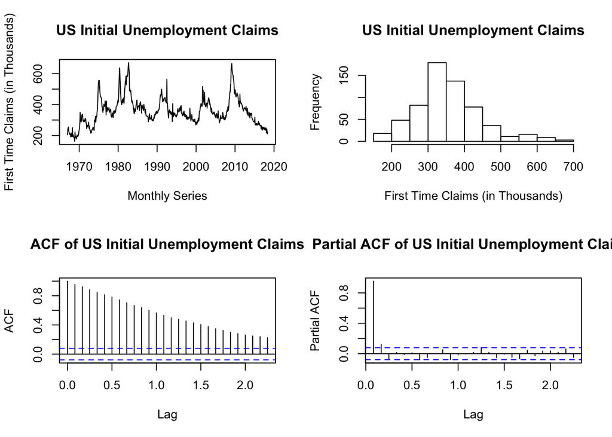

```r
par(mfrow=c(2,2))
plot(unemployment_ts, xlab="Monthly Series", ylab="First Time Claims (in Thousands)",
     main="US Initial Unemployment Claims")
hist(unemployment_ts, xlab="First Time Claims (in Thousands)",
     main="US Initial Unemployment Claims")
acf(unemployment_ts, main="ACF of US Initial Unemployment Claims")
pacf(unemployment_ts, main="Partial ACF of US Initial Unemployment Claims")
```

Now we will show some smoothing techniques.

### Moving Averages

First, we use `filter(...)` to calculate moving averages.

```r
# calculate moving averages
# explicitly calling stats::filter so we don't get dplyr::filter
ma3 <- stats::filter(unemployment_df$thousands, rep(1,3)/3, sides=2)  # 3 months
ma40 <- stats::filter(unemployment_df$thousands, sides=2, rep(1,40)/40)  # 40 months

# convert the moving averages to ts objects
ma3_ts <- ts(ma3, start=c(1967,1), freq=12)
ma40_ts <- ts(ma40, start=c(1967,1), freq=12)

# use ts.plot to overlay multiple time series
par(mfrow=c(1,1))
```

[output not shown]

### Polynomial Regression Smoother

Now we’ll try a regression smoother with a 3rd degree polynomial.

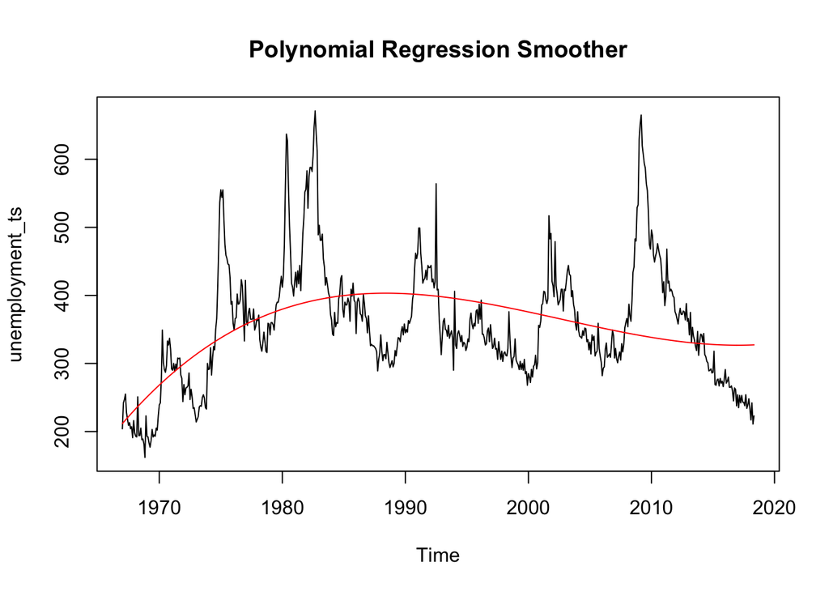

```r
# fit a polynomial regression
mo <- time(unemployment_ts) - mean(time(unemployment_ts))
mo_squared <- mo^2
mo_cubed <- mo^3
reg_smoother <- lm(unemployment_ts ~ mo + mo_squared + mo_cubed, na.action=NULL)

# plot the individual components and the regression
# par(mfrow=c(2,2))
# plot(mo)
# plot(mo_squared)
# plot(mo_cubed)
# par(mfrow=c(1,1))
plot(unemployment_ts, type="l", main="Polynomial Regression Smoother")
lines(fitted(reg_smoother), col="red")
```

This smoother is not a particularly good choice for this dataset. It does not capture the trend dynamics well for the last 10-15 years.

### Spline Smoother

We let R calculate the splines. We have to play around with the `spar` parameter.

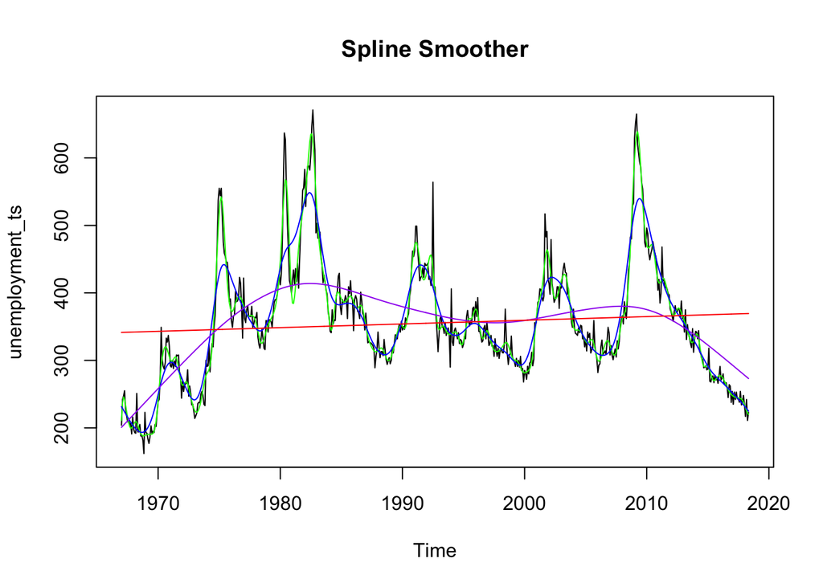

```r
plot(unemployment_ts, type="l", main="Spline Smoother")
lines(smooth.spline(time(unemployment_ts), unemployment_ts, spar=0), col="green")
lines(smooth.spline(time(unemployment_ts), unemployment_ts, spar=0.5), col="blue")
lines(smooth.spline(time(unemployment_ts), unemployment_ts, spar=1), col="purple")
lines(smooth.spline(time(unemployment_ts), unemployment_ts, spar=2), col="red")
```

The purplse and red smoothers don’t capture enough of the pattern of the data.

### Kernel Smoother

Kernel smoothing can usually capture the underlying trend very smoothly. We have to play around with the kernel function (e.g. “normal”) and with the bandwidth (how wide is the window being used for the calculation).

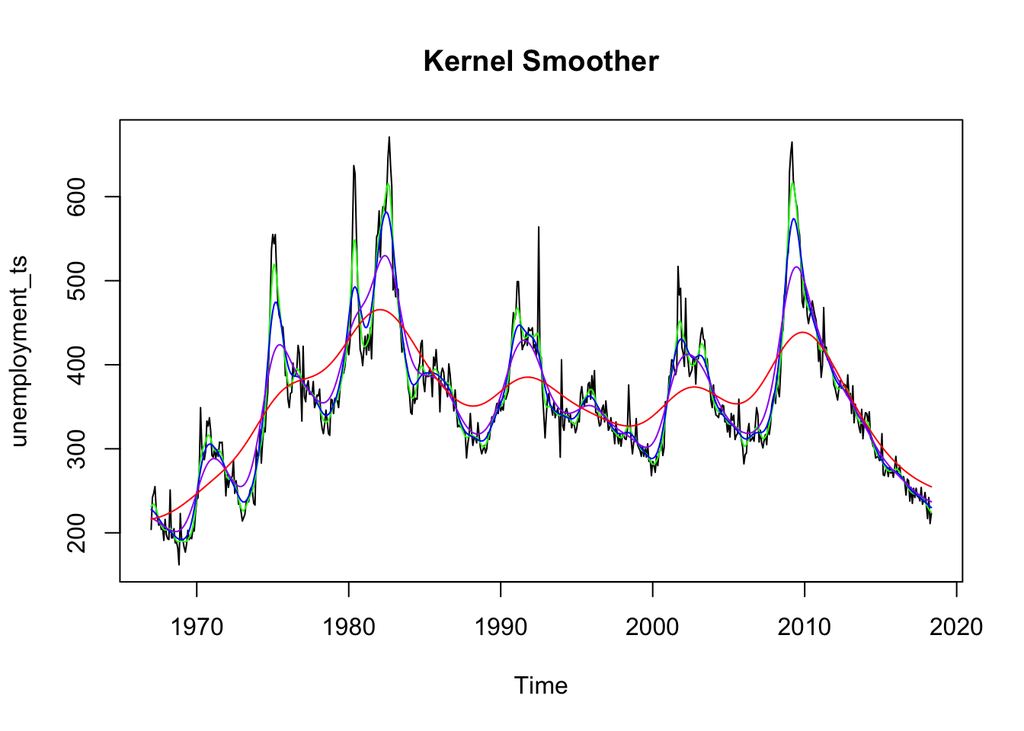

```r
plot(unemployment_ts, type="l", main="Kernel Smoother")
lines(ksmooth(time(unemployment_ts), unemployment_ts, "normal", bandwidth=0.5), col="green")
lines(ksmooth(time(unemployment_ts), unemployment_ts, "normal", bandwidth=1), col="blue")
lines(ksmooth(time(unemployment_ts), unemployment_ts, "normal", bandwidth=2), col="purple")
lines(ksmooth(time(unemployment_ts), unemployment_ts, "normal", bandwidth=5), col="red")
```

### Exponential Smoother

We use a time series without any clear trend or seasonality for this example:

```r
url <- 'https://raw.githubusercontent.com/mwinton/Introductory_Time_Series_with_R_datasets/master/motororg.dat'
complaints_df <- read.table(url, header=TRUE)
complaints_ts <- ts(complaints_df$complaints, start=c(1996, 1), frequency=12)
par(mfrow=c(1,1))
# need to set beta, gamma=FALSE for exponential smoothing
(exp_smooth <- HoltWinters(complaints_ts, alpha=0.2, beta=FALSE, gamma=FALSE))
```

```
## Holt-Winters exponential smoothing without trend and without seasonal component.
##
## Call:
## HoltWinters(x = complaints_ts, alpha = 0.2, beta = FALSE, gamma = FALSE)
##
## Smoothing parameters:
##  alpha: 0.2
##  beta : FALSE
##  gamma: FALSE
##
## Coefficients:
##    [,1]
## a 17.98
```

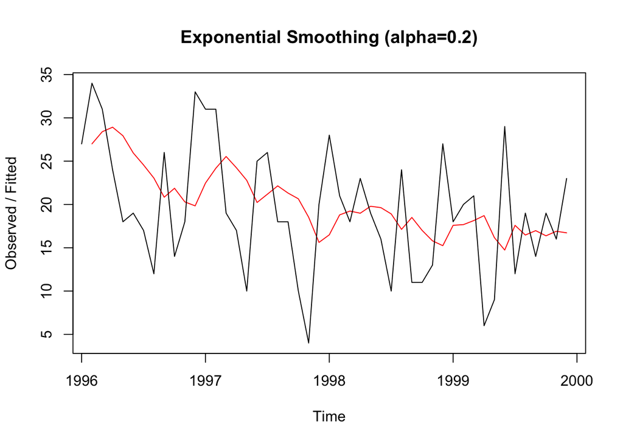

```r
# plot command plots the data and smoother
plot(exp_smooth, main="Exponential Smoothing (alpha=0.2)")
```

## Eliminating the Trend

1. Estimate a (linear) trend for the series
2. Detrend the series - subtract the trend from the observed series
3. Model residuals using a stationary model

Again, we’ll work with the global temperature data.

```r
# use the dataset from astsa
library(astsa)
str(gtemp)
```

```
##  Time-Series [1:130] from 1880 to 2009: -0.28 -0.21 -0.26 -0.27 -0.32 -0.32 -0.29 -0.36 -0.27 -0.17 ...
```

```r
time(gtemp)  # good summary to make sure we know the frequency of the data
```

```
## Time Series:
## Start = 1880
## End = 2009
## Frequency = 1
##   [1] 1880 1881 1882 1883 1884 1885 1886 1887 1888 1889 1890 1891 1892 1893
##  [15] 1894 1895 1896 1897 1898 1899 1900 1901 1902 1903 1904 1905 1906 1907
##  [29] 1908 1909 1910 1911 1912 1913 1914 1915 1916 1917 1918 1919 1920 1921
##  [43] 1922 1923 1924 1925 1926 1927 1928 1929 1930 1931 1932 1933 1934 1935
##  [57] 1936 1937 1938 1939 1940 1941 1942 1943 1944 1945 1946 1947 1948 1949
##  [71] 1950 1951 1952 1953 1954 1955 1956 1957 1958 1959 1960 1961 1962 1963
##  [85] 1964 1965 1966 1967 1968 1969 1970 1971 1972 1973 1974 1975 1976 1977
##  [99] 1978 1979 1980 1981 1982 1983 1984 1985 1986 1987 1988 1989 1990 1991
## [113] 1992 1993 1994 1995 1996 1997 1998 1999 2000 2001 2002 2003 2004 2005
## [127] 2006 2007 2008 2009
```

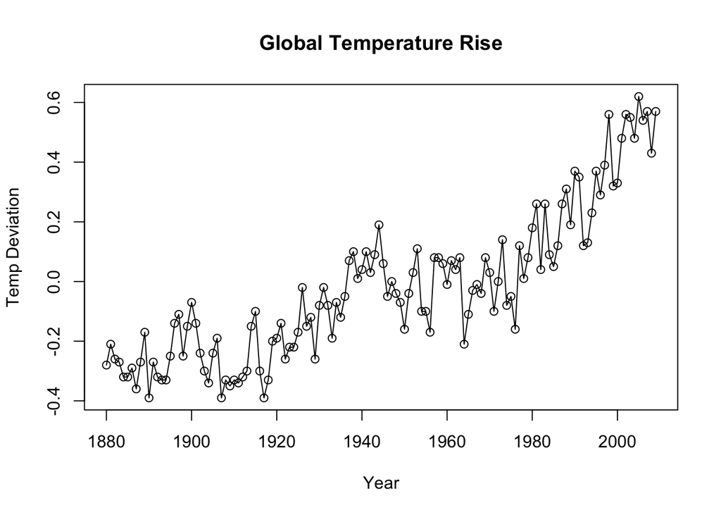

```r
# plot time series
plot(gtemp, type="o", xlab="Year", ylab="Temp Deviation", main="Global Temperature Rise")
```

First, estimate the linear trend:

```r
# 1. estimate linear trend
gtemp_lt <- lm(gtemp ~ time(gtemp), na.action=NULL)
summary(gtemp_lt)
```

```
##
## Call:
## lm(formula = gtemp ~ time(gtemp), na.action = NULL)
##
## Residuals:
##     Min      1Q  Median      3Q     Max
## -0.3195 -0.0972  0.0008  0.0825  0.2938
##
## Coefficients:
##              Estimate Std. Error t value Pr(>|t|)
## (Intercept) -1.12e+01   5.69e-01   -19.7   <2e-16 ***
## time(gtemp)  5.75e-03   2.92e-04    19.6   <2e-16 ***
## ---
## Signif. codes:  0 '***' 0.001 '**' 0.01 '*' 0.05 '.' 0.1 ' ' 1
##
## Residual standard error: 0.125 on 128 degrees of freedom
## Multiple R-squared:  0.751,  Adjusted R-squared:  0.749
## F-statistic:  386 on 1 and 128 DF,  p-value: <2e-16
```

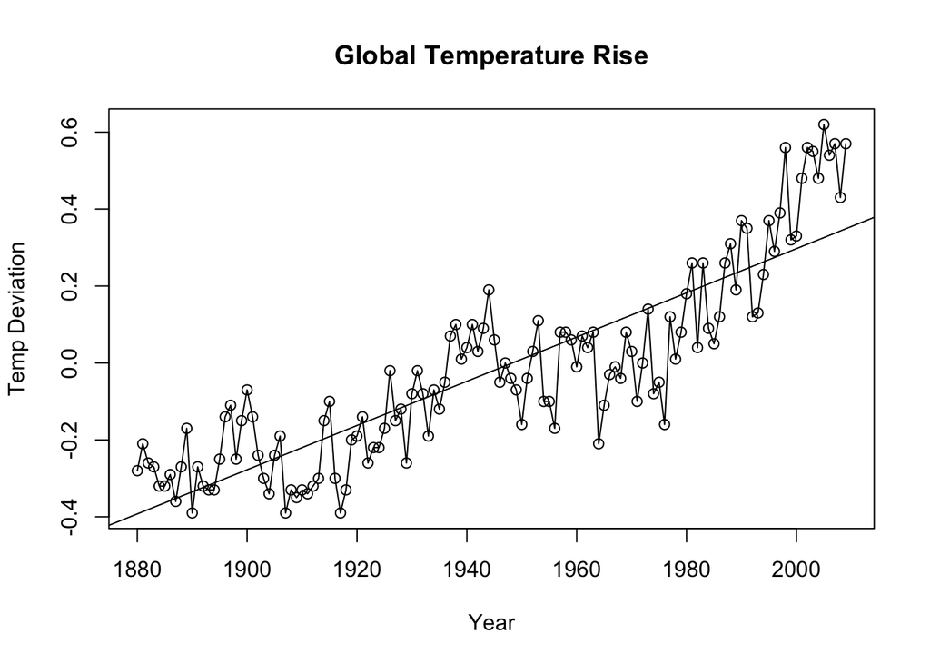

```r
plot(gtemp, type="o", xlab="Year", ylab="Temp Deviation", main="Global Temperature Rise")
abline(gtemp_lt)
```

Then we detrend the series; plotting the residuals shows the results:

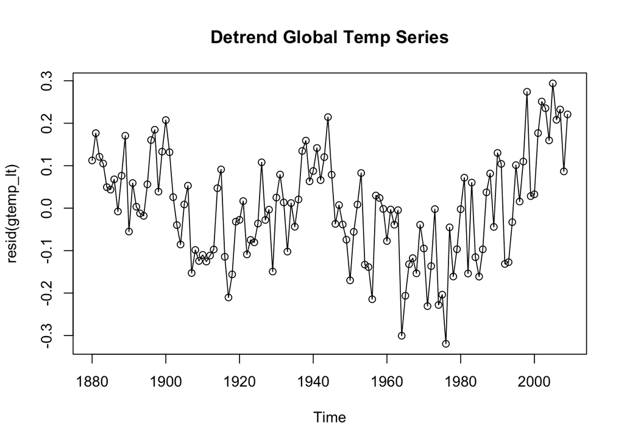

```r
# 2. detrend the series
plot(resid(gtemp_lt), type="o", main="Detrend Global Temp Series")
```

This did a pretty good for the majority of the series. (Not quite as good at the right; polynomial fits might do a better job detrending this dataset.) If we desire to model the stationary series, we model these residuals with a stationary model. We also will need to establish whether the stationarity assumption is valid.

### First Differencing

Note that there’s also another approach we could take: *First Differencing*. We want to “undifference” the series when we want to do forecasting.

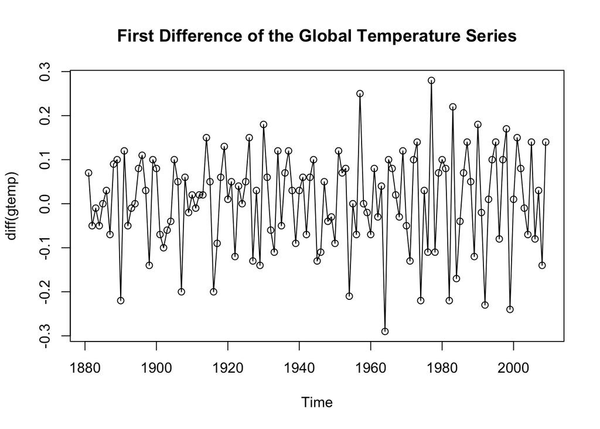

```r
plot(diff(gtemp), type="o", main="First Difference of the Global Temperature Series")
```